# CMV NGS Data Analysis

Osman Merdan

2023-01-06

## 0.1 Brief Summary of Data And Data Source

All bash and R-scripts and python notebooks related to the current project have been shared in the GitHub repository https://github.com/osmanmerdan/Congenital-CMV. Tool parameters have been explained in detail in scripts files.

This project *does not* aim to find optimal best practices to analyze CMV NGS data. For readers who are interested in a user-friendly, fast, all-in-one solution to analyze the CMV genome, please check GRACy(Camiolo et al. (2021)). This HTML document was created using RMarkdown. Plots were created using the ggplot package if otherwise are not indicated.

## 0.2 CMV Viral Particle

Human cytomegalovirus formally known as Human Herpes Virus 5 (HHV5) is a member of *Herpesviridae* family. HHV-6, HHV-7, and CMV are classified as *betaherpesviruses*.

Complete HCMV particles have a diameter of 120-200 nm. HCMV nucleocapsid encircles large (220- to 240-kb) linear double-stranded DNA genome. Outside of nucleocapsid there is matrix and a surrounding phospholipid-rich envelope.

The HCMV genome is the largest among herpesviruses. It consists of more than 170 nonoverlapping ORFs (Open Reading Frames). Genome encodes structural, regulatory and immune modulatory proteins.

CMV is one of most important pathogenes causing congenital infections ultimately leading sensorineural hearing loss and neurodevelopmental problems.

HCMV DNA enters the host cell in linear form. HCMV genome has an unpaired base at each end which facilitates circularization of the genome which enables rolling circle replication. This replication mechanism creates genome length covalently linked copies of viral genome which are called concatemer. Concatemers are later cleved.

HCMV genome has class E organization with two domains that can be inverted relative to each other *(Fig 1)*. That organization yields equal amounts of four genomic isomers that can be isolated from samples. These two domains are the long and short genome segments (L and S). Each domain contains a unique central region (UL and US). Those regions are flanked by repeated components that reside at either the terminal regions of the genome (TRL and TRS) or intersection of L and S segments (IRL and IRS). General organization of HCMV genome is TRL-UL-IRL -IRS-US-TRS. Terminal end internal repeats shares a region of couple of hundreds bps, called *a* sequence.

[figure not shown]

Fig 1: CMV wild type Merlin strain structure and possible isomers

## 0.3 Quality Control Of Trimmed and Filtered NGS Data

Paired end seqeunce data of 36 samples were downloaded from SRA using sratoolkit (3.0.0) fastq-dump. Reads were timmed with Trimmomatic (Bolger, Lohse, and Usadel (2014)) (version 0.39). The minimum sequence length was set to 200 bp. After Trimmomatic operations, FastQC (“FastQC” (2015)) and MultiQC (Ewels et al. (2016)) were performed to get summary statistics about raw-filtered NGS data.

The below table shows some of the summary statistics.

| Sample | Pair | Total Sequences | Sequences flagged as poor quality | Sequence length | % GC | total_deduplicated_percentage | avg_sequence_length | basic_statistics | per_base_sequence_quality | per_sequence_quality_scores | per_base_sequence_content | per_sequence_gc_content | per_base_n_content | sequence_length_distribution | sequence_duplication_levels | overrepresented_sequences | adapter_content |
| --- | --- | --- | --- | --- | --- | --- | --- | --- | --- | --- | --- | --- | --- | --- | --- | --- | --- |
| ERR7018437 | 1 | 242167 | 0 | 200-251 | 55 | 34.576553 | 247.9180 | pass | pass | pass | warn | fail | pass | warn | fail | pass | pass |
| ERR7018437 | 2 | 242167 | 0 | 200-251 | 54 | 34.992381 | 229.7144 | pass | pass | pass | warn | fail | pass | warn | fail | pass | pass |
| ERR7018441 | 1 | 165580 | 0 | 200-251 | 56 | 30.719894 | 247.5181 | pass | pass | pass | warn | fail | pass | warn | fail | pass | pass |
| ERR7018441 | 2 | 165580 | 0 | 200-251 | 55 | 30.909530 | 229.4626 | pass | pass | pass | warn | warn | pass | warn | fail | pass | pass |
| ERR7018443 | 1 | 4508 | 0 | 200-251 | 46 | 79.991127 | 243.4827 | pass | pass | pass | warn | fail | pass | warn | pass | warn | pass |
| ERR7018443 | 2 | 4508 | 0 | 200-251 | 46 | 80.412600 | 227.3518 | pass | pass | pass | fail | fail | pass | warn | pass | warn | pass |
| ERR7018450 | 1 | 533885 | 0 | 200-251 | 55 | 52.683416 | 243.0476 | pass | pass | pass | warn | fail | pass | warn | warn | pass | pass |
| ERR7018450 | 2 | 533885 | 0 | 200-251 | 55 | 52.506227 | 229.6907 | pass | pass | pass | warn | fail | pass | warn | warn | pass | pass |
| ERR7018455 | 1 | 403037 | 0 | 200-251 | 54 | 51.706527 | 245.9994 | pass | pass | pass | warn | fail | pass | warn | warn | pass | pass |
| ERR7018455 | 2 | 403037 | 0 | 200-251 | 54 | 52.561038 | 230.2000 | pass | pass | pass | warn | fail | pass | warn | warn | pass | pass |

[output cut: 62 more lines]

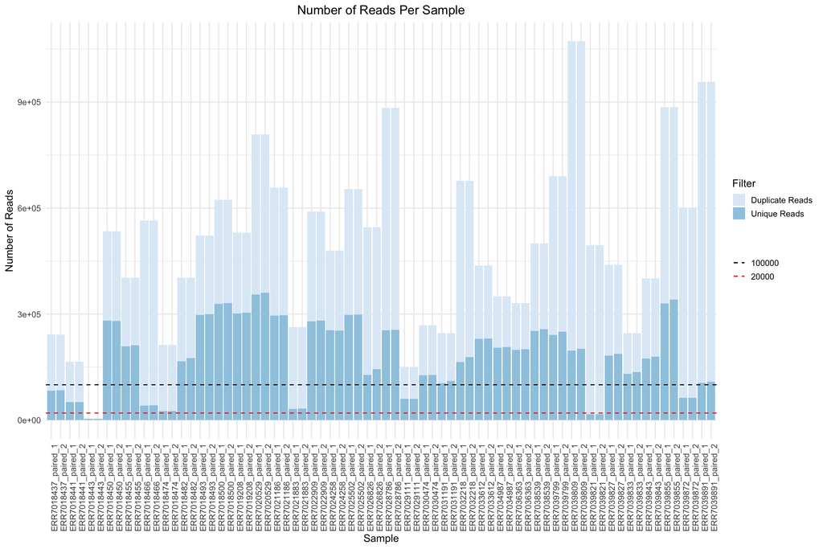

Plot 1: The number of unique and duplicated reads in each trimmed sequencing record, estimated by FastQC.

HCMV *wild-type* strain Merlin genome size is 235646 bp. To achieve reliable results from the variant analysis, at least a 20 bp coverage threshold has been set in present NGS data analysis project. That means at least 20000 (200bp long) reads are needed *(red line in the Plot 1)*. Some of the low unique read count samples are:

| Sample | Filter | Number of Reads |
| --- | --- | --- |
| ERR7018443_paired_1 | Unique Reads | 3607 |
| ERR7018443_paired_2 | Unique Reads | 3626 |
| ERR7018466_paired_1 | Unique Reads | 41126 |
| ERR7018466_paired_2 | Unique Reads | 42009 |
| ERR7018474_paired_1 | Unique Reads | 25906 |
| ERR7018474_paired_2 | Unique Reads | 25892 |
| ERR7021883_paired_1 | Unique Reads | 32109 |
| ERR7021883_paired_2 | Unique Reads | 32396 |
| ERR7039821_paired_1 | Unique Reads | 16779 |
| ERR7039821_paired_2 | Unique Reads | 16841 |

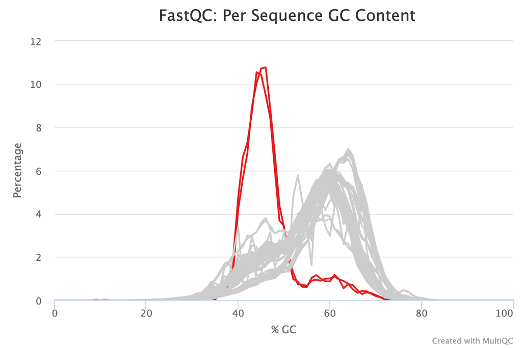

Fig 2: ERR7018443 (red) and other samples’ percent GC contents (gray).

HCMV Merlin strain genome has a GC content of %57. All the samples had some level of deviation from the expected %57, which several issues like contamination, PCR bias, low genome coverage, and hypervariable regions in the CMV genomes may have caused *(Fig 2)*.

Mean quality scores were sufficient enough for downstream analysis *(Fig 3)*.

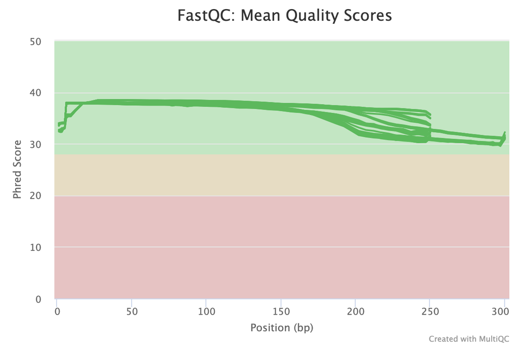

Fig 3: Base quality

## 0.4 Alignment Results

Reads were aligned to *Human herpesvirus five strain Merlin, complete genome* (GenBank Accession: AY446894.2) using BWA-MEM (Heng Li (2013)) (Version: 0.7.17-r1188). Alignment files were filtered and sorted using Samtools (Danecek et al. (2021)) (Version: 1.16.1). Output bam files were de-duplicated using Picard MarkDuplicates (“Picard Toolkit” (2018)).  
Some important summary results from de duplicated-bam alignment files were presented below.

| sampleID | name | start | end | numreads | covbasses | coverage | meandepth | meanbaseq | meanmapq |
| --- | --- | --- | --- | --- | --- | --- | --- | --- | --- |
| ERR7018437 | AY446894.2 | 1 | 235646 | 133542 | 223758 | 94.9551 | 134.872000 | 37.1 | 59.9 |
| ERR7018441 | AY446894.2 | 1 | 235646 | 74567 | 226520 | 96.1272 | 75.931000 | 37.2 | 60.0 |
| ERR7018443 | AY446894.2 | 1 | 235646 | 1080 | 129090 | 54.7813 | 1.041490 | 36.9 | 59.8 |
| ERR7018450 | AY446894.2 | 1 | 235646 | 927915 | 224058 | 95.0825 | 919.030000 | 37.0 | 60.0 |
| ERR7018455 | AY446894.2 | 1 | 235646 | 508385 | 224345 | 95.2042 | 506.936000 | 37.0 | 60.0 |
| ERR7018466 | AY446894.2 | 1 | 235646 | 32915 | 224683 | 95.3477 | 33.062200 | 37.2 | 60.0 |
| ERR7018474 | AY446894.2 | 1 | 235646 | 920 | 91605 | 38.8740 | 0.799182 | 37.0 | 58.0 |
| ERR7018482 | AY446894.2 | 1 | 235646 | 339374 | 222538 | 94.4374 | 337.792000 | 37.0 | 59.9 |
| ERR7018493 | AY446894.2 | 1 | 235646 | 967097 | 222976 | 94.6233 | 954.074000 | 36.6 | 59.9 |
| ERR7018500 | AY446894.2 | 1 | 235646 | 1150628 | 224520 | 95.2785 | 1134.240000 | 36.7 | 59.9 |

[output cut: 26 more lines]

Samples with mean depth lower than 20 or coverage lower than 90% were listed below.

| sampleID | name | start | end | numreads | covbasses | coverage | meandepth | meanbaseq | meanmapq |
| --- | --- | --- | --- | --- | --- | --- | --- | --- | --- |
| ERR7018443 | AY446894.2 | 1 | 235646 | 1080 | 129090 | 54.7813 | 1.041490 | 36.9 | 59.8 |
| ERR7018474 | AY446894.2 | 1 | 235646 | 920 | 91605 | 38.8740 | 0.799182 | 37.0 | 58.0 |
| ERR7021883 | AY446894.2 | 1 | 235646 | 16116 | 222469 | 94.4081 | 15.910500 | 37.1 | 59.8 |
| ERR7029111 | AY446894.2 | 1 | 235646 | 13365 | 226233 | 96.0054 | 13.219400 | 37.0 | 59.7 |
| ERR7039821 | AY446894.2 | 1 | 235646 | 5879 | 212631 | 90.2332 | 5.530390 | 37.2 | 59.6 |

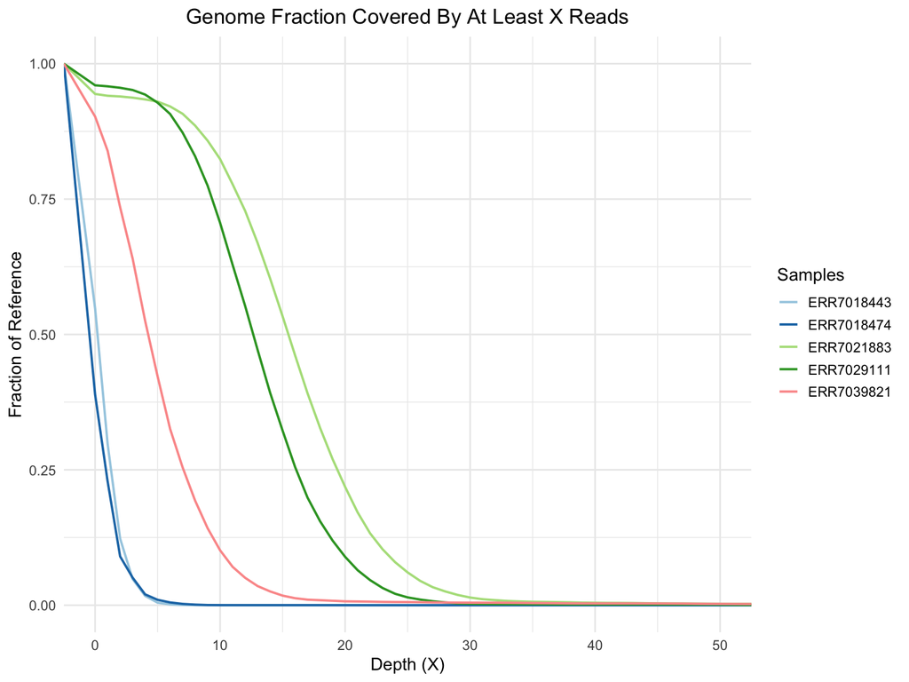

Plot 2: Empirical cumulative density function (complementary) visualization for low-coverage low-mean-depth samples

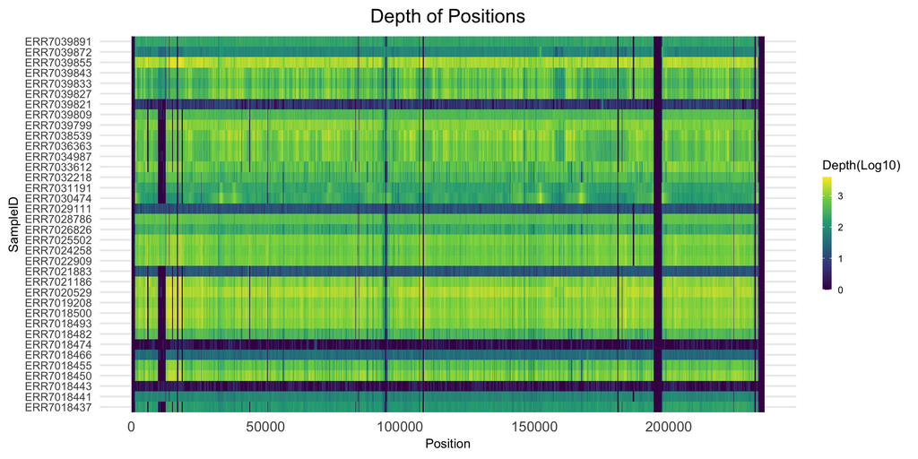

Fig 4: Depth of coverage heat map with log transformed values

There were three regions not covered in any sample, in the beginning, at the end, and around the 200000th position *(Fig 4)*. Those regions correspond to TRL, TRS, IRS, and IRL regions in AY446894.2, which are listed below.

| Name | Location | Repeat-Type |
| --- | --- | --- |
| TRL | [0:1324](+) | inverted |
| 'a' sequence | [0:578](+) | direct, terminal |
| OriLyt-associated repeat | [94058:94198](+) | None |
| IRL | [194343:195667](+) | inverted |
| IRS | [195089:197626](+) | inverted |
| 'a' sequence | [195089:195667](+) | inverted |
| TRS | [233108:235646](+) | inverted |
| 'a' sequence | [235067:235646](+) | direct, terminal |

However, there were indications of possible deletions around positions 6000 and 11000 *(Plot 3)*. Record ERR7036363 had zero depth in those two regions *(Plot 3)*. ERR7032218 showed signs of deletion only around position 11000. ERR7024258 was included for comparison.

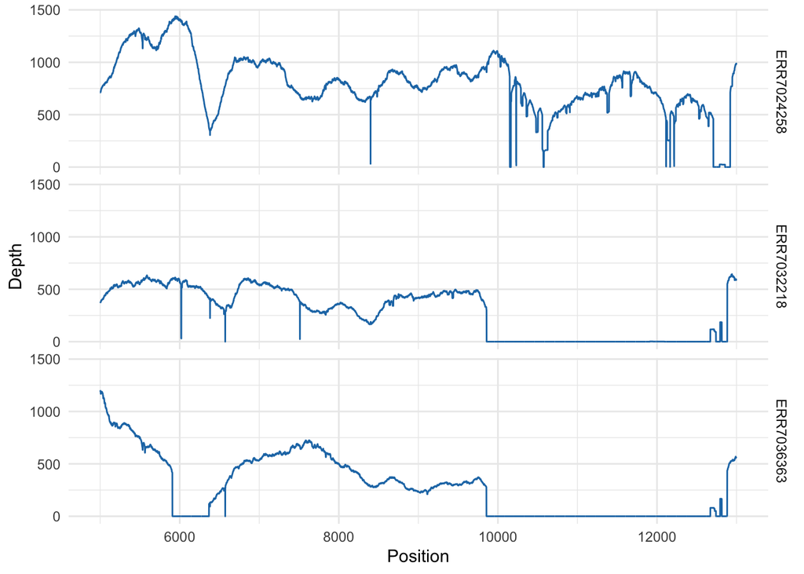

Plot 3 : Positions between 5000-13000 for samples ERR7036363, ERR7032218, ERR7024258.

ERR7036363 showed significant sequence variation in the RL6 gene, as indicated by soft-clipped reads *(Fig 5)*. That’s why ER7036363 had zero reads mapped at corresponding positions. ERR7032218 has some SNPs and a deletion in the RL6 gene *(Fig 5)*. ERR7024258 has nucleotide content very similar to the Merlin strain at corresponding parts *(Fig 5)*.

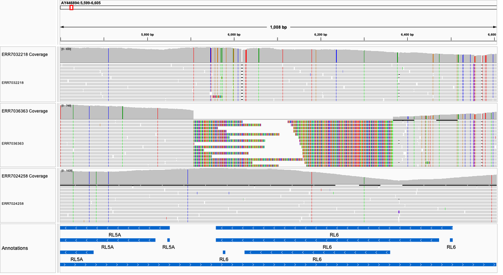

Fig 5: IGV snapshot zoomed in positions between 5600-6600

ERR7036363 and ERR7032218 showed significant sequence variation with signs of possible deletion in regions corresponding to the genes RL11, RL12, RL13, and UL1 *(Fig 6)*. In addition, ERR7024258 has many sequence variations compared to the Merlin strain in these gene regions *(Fig 6)*.

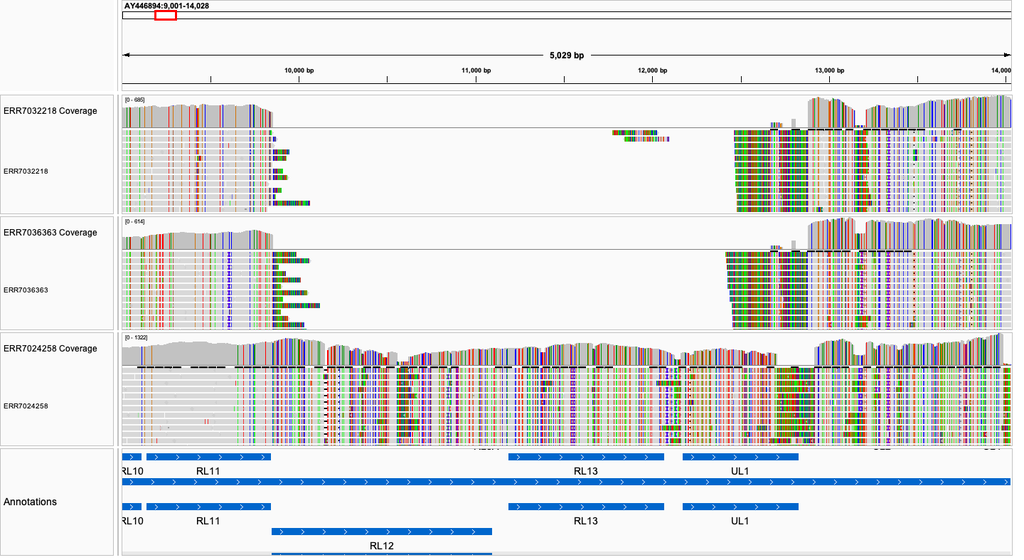

Fig 6: IGV snapshot zoomed in positions between 9000-14000

RL6, RL12, RL13, and UL1 genes are members of the RL11 gene family. These regions are known for showing sequence variations between clinical isolates. (Sijmons, Van Ranst, and Maes (2014), Dolan et al. (2004))

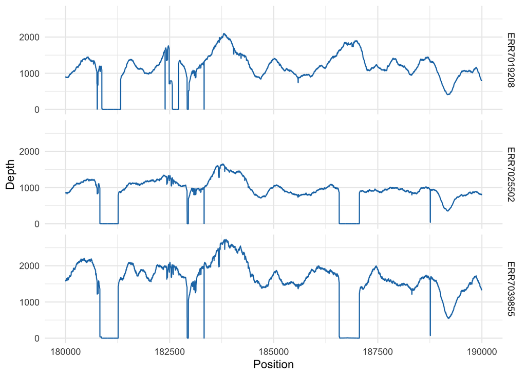

Plot 4: Positions between 180000-190000 for samples ERR7039855, ERR7019208, and ERR7025502

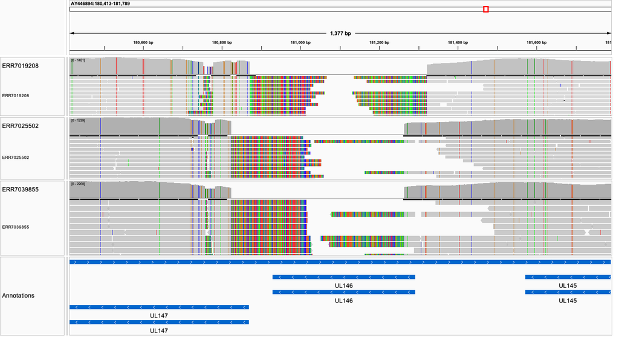

Another region showing sequence variation between different HCMV clinical isolates is the UL139 region (Qi et al. (2006)). The alignment status of reads belonging to ERR7025502, and ERR7039855 showed sequence variation in UL139-150A regions.

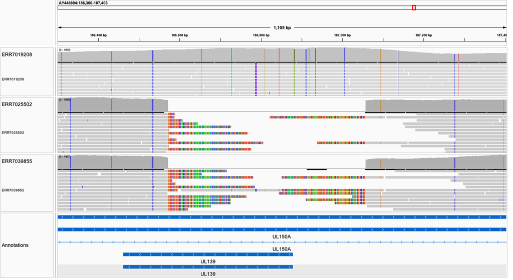

In summary, CMV has a lot of regions that pose high levels of sequence variation between clinical strains. Those regions could be rendered as low-coverage, low-depth regions during alignment process.

## 0.5 Variants

Variants were called on deduplicated-bam files and filtered using bcftools (version 1.16).(H. Li (2011)). Later SnpEff database for AY446894.2 was build following instructions shared on SnpEff website. (http://pcingola.github.io/SnpEff/se_faq/#how-to-building-an-ncbi-genome-genbank-file) Variants in coding regions were annotated using SnpEff (Cingolani, Platts, et al. (2012)). Annotated variants were extracted with SnpSift (Cingolani, Patel, et al. (2012)). Number of different annotations were summarized below table.

| SampleID | EFFECT | Number of Variations |
| --- | --- | --- |
| ERR7039809 | synonymous_variant | 2333 |
| ERR7034987 | synonymous_variant | 2312 |
| ERR7036363 | synonymous_variant | 2306 |
| ERR7018437 | synonymous_variant | 2305 |
| ERR7018482 | synonymous_variant | 2299 |
| ERR7019208 | synonymous_variant | 2292 |
| ERR7018500 | synonymous_variant | 2289 |
| ERR7038539 | synonymous_variant | 2289 |
| ERR7018493 | synonymous_variant | 2286 |
| ERR7021186 | synonymous_variant | 2283 |

[output cut: 372 more lines]

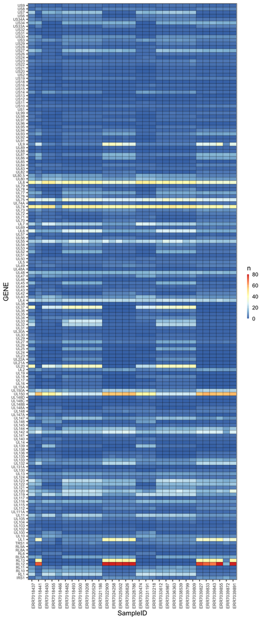

Plot 5: Heatmap summarizing number of non-synonymous SNPs for each sample and gene combination

Some samples had a high number of non-synonymous SNPs at regions RL12 and RL13 *(Plot 5, Plot 6)*. However, nearly half of the samples had zero non-synonymous SNP in RL12 and RL13 *(Plot 6)*. A higher number of non-synonymous SNPs were observed in UL8, UL74, UL75, and UL150 genes *(Plot 5, Plot 6)*. The products of these genes were summarized in the following table.

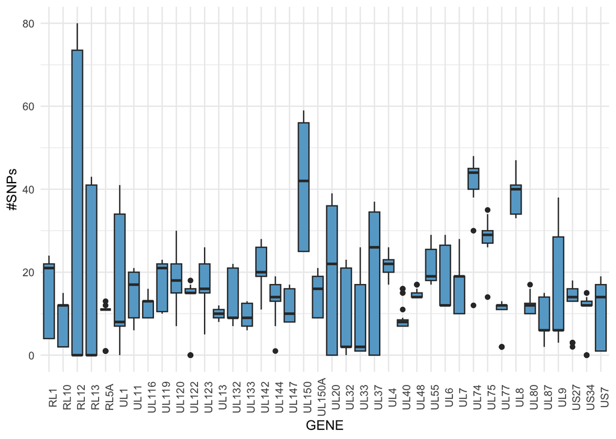

Plot 6: Box plots for genes with more than ten mean # of non-synonymous SNPs.

| Gene | Position | Product | Note |
| --- | --- | --- | --- |
| RL1 | [1366:2299](+) | protein RL1 | RL1 family |
| RL5A | [5388:5676](-) | protein RL5A | RL11 family |
| RL10 | [8600:9113](+) | envelope glycoprotein RL10 | type 1 membrane protein; possibly related to RL11 family |
| RL12 | [9849:11094](+) | membrane protein RL12 | type 1 membrane protein; RL11 family |
| RL13 | [11188:12070](+) | membrane protein RL13 | type 1 membrane protein; RL11 family; consensus is wild type, consisting of several mutants present in different populations |
| UL1 | [12173:12830](+) | membrane protein UL1 | type 1 membrane protein; RL11 family |
| UL4 | [13820:14270](+) | envelope glycoprotein UL4 | contains signal peptide; RL11 family |
| UL6 | [14964:15807](+) | membrane protein UL6 | type 1 membrane protein; RL11 family |
| UL8 | join{[15864:16449](+), [16551:16941](+)} | membrane glycoprotein UL8 | type 1 membrane protein; RL11 family |
| UL7 | [15864:16533](+) | membrane glycoprotein UL7 | type 1 membrane protein; modulates cytokine production; involved in immune regulation; RL11 family |

[output cut: 30 more lines]

Bolger, Anthony M., Marc Lohse, and Bjoern Usadel. 2014. “Trimmomatic: A Flexible Trimmer for Illumina Sequence Data.” *Bioinformatics* 30 (15): 2114–20. https://doi.org/10.1093/bioinformatics/btu170.

Camiolo, Salvatore, Nicolás M Suárez, Antonia Chalka, Cristina Venturini, Judith Breuer, and Andrew J Davison. 2021. “GRACy: A Tool for Analysing Human Cytomegalovirus Sequence Data.” *Virus Evolution* 7 (1): veaa099. https://doi.org/10.1093/ve/veaa099.

Cingolani, P., V. M. Patel, M. Coon, T. Nguyen, S. J. Land, D. M. Ruden, and X. Lu. 2012. “Using Drosophila Melanogaster as a Model for Genotoxic Chemical Mutational Studies with a New Program, SnpSift.” *Frontiers in Genetics* 3.

Cingolani, P., A. Platts, M. Coon, T. Nguyen, L. Wang, S. J. Land, X. Lu, and D. M. Ruden. 2012. “A Program for Annotating and Predicting the Effects of Single Nucleotide Polymorphisms, SnpEff: SNPs in the Genome of Drosophila Melanogaster Strain W1118; Iso-2; Iso-3.” *Fly* 6 (2): 80–92.

Danecek, Petr, James K Bonfield, Jennifer Liddle, John Marshall, Valeriu Ohan, Martin O Pollard, Andrew Whitwham, et al. 2021. “Twelve years of SAMtools and BCFtools.” *GigaScience* 10 (2). https://doi.org/10.1093/gigascience/giab008.

Dolan, Aidan, Charles Cunningham, Ralph D. Hector, Aycan F. Hassan-Walker, Lydia Lee, Clare Addison, Derrick J. Dargan, et al. 2004. “Genetic Content of Wild-Type Human Cytomegalovirus.” *Journal of General Virology* 85 (5): 1301–12. https://doi.org/10.1099/vir.0.79888-0.

Ewels, Philip, Måns Magnusson, Sverker Lundin, and Max Käller. 2016. “MultiQC: Summarize Analysis Results for Multiple Tools and Samples in a Single Report.” *Bioinformatics* 32 (19): 3047. https://doi.org/10.1093/bioinformatics/btw354.

“FastQC.” 2015. https://qubeshub.org/resources/fastqc.

Li, H. 2011. “A Statistical Framework for SNP Calling, Mutation Discovery, Association Mapping and Population Genetical Parameter Estimation from Sequencing Data.” *Bioinformatics* 27 (21): 2987–93. https://doi.org/10.1093/bioinformatics/btr509.

Li, Heng. 2013. “Aligning Sequence Reads, Clone Sequences and Assembly Contigs with BWA-MEM.” https://doi.org/10.48550/ARXIV.1303.3997.

“Picard Toolkit.” 2018. *Broad Institute, GitHub Repository*. http://broadinstitute.github.io/picard/; Broad Institute.

Qi, Ying, Zhi-Qin Mao, Qiang Ruan, Rong He, Yan-Ping Ma, Zheng-Rong Sun, Yao-Hua Ji, and Yujing Huang. 2006. “Human Cytomegalovirus (HCMV) UL139 Open Reading Frame: Sequence Variants Are Clustered into Three Major Genotypes.” *Journal of Medical Virology* 78 (4): 517–22. https://doi.org/10.1002/jmv.20571.

Sijmons, Steven, Marc Van Ranst, and Piet Maes. 2014. “Genomic and Functional Characteristics of Human Cytomegalovirus Revealed by Next-Generation Sequencing.” *Viruses* 6 (3): 1049–72. https://doi.org/10.3390/v6031049.

Ye, Lele, Yunyun Qian, Weijie Yu, Gangqiang Guo, Hong Wang, and Xiangyang Xue. 2020. “Functional Profile of Human Cytomegalovirus Genes and Their Associated Diseases: A Review.” *Frontiers in Microbiology* 11 (September): 2104. https://doi.org/10.3389/fmicb.2020.02104.